# analysing_daily_dispatch_summary

```python
import numpy as np
import pandas as pd
import scipy
import matplotlib.pyplot as plt
import seaborn as sns
import random
import json
import datetime, time
import pickle
```

```python
with open("daily_dispatch_summary_18-01-19.json") as f:
    a = f.readlines()
    json_data = [json.loads(i) for i in a]
```

```python
for i in range(len(json_data)):
    json_data[i]['Sales Order Date'] = json_data[i]['Sales Order Date']['$date']['$numberLong']
    json_data[i]['Loading Date'] = json_data[i]['Loading Date']['$date']['$numberLong']
```

```python
df = pd.DataFrame.from_dict(json_data).drop(columns = ['_id', 'HEAP ID'])
```

```python
df['Sales Order Date'] = df['Sales Order Date'].apply(lambda x : datetime.datetime.fromtimestamp(int(x[:10])))
df['Loading Date'] = df['Loading Date'].apply(lambda x : datetime.datetime.fromtimestamp(int(x[:10])))

df['Quality Lifted'] = df['Quality Lifted'].astype('float')
```

## Exploring The Data

```python
for i in list(df.columns):
    print(i, end = ' , ')
```

```
Consignee Name , Grade& Size(Product Description) , Loading Date , Quality Lifted , Sales Order Date , Sales Order No , area_id , area_name , colliery_id , colliery_name ,
```

```python
df.info()
```

[output not shown]

```python
df.describe()
```

|  | Consignee Name | Grade& Size(Product Description) | Loading Date | Quality Lifted | Sales Order Date | Sales Order No | area_id | area_name | colliery_id | colliery_name |
| --- | --- | --- | --- | --- | --- | --- | --- | --- | --- | --- |
| count | 593535 | 593535 | 593535 | 593535 | 593535 | 593535 | 593535 | 593535 | 593535 | 593535 |
| unique | 909 | 43 | 384 | 1964 | 325 | 21140 | 15 | 15 | 67 | 66 |
| top | M/S MAITHON RIGHT BANK THERMAL POWER PROJECT | Washery-4 ROM | 2018-07-02 05:30:00 | 20 | 2018-09-04 05:30:00 | 19000100179 | 04 | Katras Area | 0408 | West Mudidih |
| freq | 90837 | 154569 | 2343 | 5234 | 12973 | 2755 | 147133 | 147133 | 78591 | 78591 |
| first | NaN | NaN | 2018-01-01 05:30:00 | NaN | 2017-11-17 05:30:00 | NaN | NaN | NaN | NaN | NaN |
| last | NaN | NaN | 2019-01-19 05:30:00 | NaN | 2019-01-15 05:30:00 | NaN | NaN | NaN | NaN | NaN |

#### Checking for the number of null values in the Dataset

```python
df.isnull().sum()
```

```
Consignee Name                      0
Grade& Size(Product Description)    0
Loading Date                        0
Quality Lifted                      0
Sales Order Date                    0
Sales Order No                      0
area_id                             0
area_name                           0
colliery_id                         0
colliery_name                       0
dtype: int64
```

### Range of Records

The analysed dataset contains records for Daily Dispatch Summary for BCCL (Bharat Coking Coal Limited).  
5,93,535 Records were analysed from 17<sup>th</sup> November 2017 to 15<sup>th</sup>January 2019

```python
print(f"Data Analysed is from {np.min(df['Sales Order Date'])} to {np.max(df['Sales Order Date'])}")
```

```
Data Analysed is from 2017-11-17 05:30:00 to 2019-01-15 05:30:00
```

### How Does the Data Look Like?

```python
df.sample(5)
```

|  | Consignee Name | Grade& Size(Product Description) | Loading Date | Quality Lifted | Sales Order Date | Sales Order No | area_id | area_name | colliery_id | colliery_name |
| --- | --- | --- | --- | --- | --- | --- | --- | --- | --- | --- |
| 362423 | HALDIA ENERGY LIMITED | G8 (4901 KCal/Kg - 5200 KCal/Kg) ROM | 2018-09-23 05:30:00 | 14.44 | 2018-09-04 05:30:00 | 19004108981 | 10 | Lodna Area | 1002 | North Tisra |
| 403377 | MAITHON POWER LIMITED | G8 (4901 KCal/Kg - 5200 KCal/Kg) ROM | 2018-03-04 05:30:00 | 14.42 | 2018-02-08 05:30:00 | 18789816954 | 10 | Lodna Area | 1026 | North Tisra - SSY |
| 402668 | MAITHON POWER LIMITED | G8 (4901 KCal/Kg - 5200 KCal/Kg) ROM | 2018-02-14 05:30:00 | 14.68 | 2018-02-08 05:30:00 | 18789816954 | 10 | Lodna Area | 1026 | North Tisra - SSY |
| 358916 | D.V.C.-RAGHUNATHPUR,TPS,PHASE-1, UNIT-1 | Washery-4 ROM(POWER PLANT) | 2018-08-16 05:30:00 | 14.88 | 2018-08-06 05:30:00 | 19710007443 | 10 | Lodna Area | 1002 | North Tisra |
| 276422 | CESC Limited | Washery-4 ROM | 2018-07-25 05:30:00 | 14.1 | 2018-07-04 05:30:00 | 19707405848 | 04 | Katras Area | 0408 | West Mudidih |

## Analysing The Data

### Consignee Name

The Name of the consignees who are responsible for completing the consignments.

- Total number of **Unique Consignees in this dataset of 5,93,535 records were 909**
  - **M/S MAITHON RIGHT BANK THERMAL POWER PROJECT** and **MAITHON POWER LIMITED** together completed **1,41,967 Consignments** accounting for roughly **24 Percent** of consignments
  - **M/S MAITHON RIGHT BANK THERMAL POWER PROJECT** and **MAITHON POWER LIMITED** together took care of 2136614.33 Quantity

```python
len(df['Consignee Name'].unique())
```

```
909
```

```python
df['Consignee Name'].value_counts()
```

```
M/S MAITHON RIGHT BANK THERMAL POWER PROJECT    90837
MAITHON POWER LIMITED                           51130
Adhunik Power And natural Resources ltd.        39144
TATA STEEL LIMITED                              39076
D.V.C.-RAGHUNATHPUR,TPS,PHASE-1, UNIT-1         32880
Jaypee Nigrie Super Thermal Power Project       32688
HALDIA ENERGY LIMITED                           31414
CESC Limited                                    28485
M/S NABHA POWER LIMITED                         22601
SAIL- CHASNALA WASHERY                          20435
DB POWER LIMITED UNIT 1                         10845
The TATA Power Company Ltd.                      9750
Jaypee Bina Thermal Power Plant                  9300
M/S PRAYAGRAJ POWER GENERATION COMPANY LTD.      5574
JAI BALAJI INDUSTRIES LIMITED                    5508
MAHARAJA                                         3265
GVK Power (Goindwal Sahib) Limited               2735
MAITHAN ALLOYS LIMITED                           2294
M/S JHAJJHAR POWER LTD.(MGTPP)                   2201
MAHADEV COKE LIMITED                             2017
KSK Mahanadi Power Company Limited               1961
M/S AKASH COKE INDUSTRIES PRIVATE LIMITED        1883
DIAMOND TRADEMART(P)LTD                          1695
SAIL- JAMADOBA WASHERY                           1582
AKASH COKE  INDUSTRIES PVT LTD                   1564
VINAYAK SUPPORT SERVICES PRIVATE LIMITED         1527
SINGH NATURAL RESOURCE PVT LTD                   1480
BASUDHA UDYOG                                    1374
SAI RAM ENTERPRISES                              1356
CHANDRAPURA THERMAL POWER STATION, DVC           1332
                                                ...
MAAA  LAXMI TRADING                                 5
SWASTIK METALS & MINERALS                           5
M/S GOPAL KUMAR                                     5
M/S PUSHPARAJ TRADERS                               5
JITENDRA YADAV                                      4
RISHAV ENTERPRISES                                  4
CHHOTE LAL                                          4
P.D.TRADERS                                         4
BHUMI TRADERS                                       4
BHAGWATI COKING COALS PRIVATE LIMITED               3
DIAMOND SMOKELESS COKE $ COAL COMPLEX               3
B K SINGH & OTHER HUF                               3
M/S SHER BAHADUR SINGH                              3
M/S ASSOCIATED TRADERS                              3
MAA BIMLA UDYOG                                     3
PALI ENTERPRISES                                    3
TANU COAL TRADERS                                   3
YASHASVI ENTERPRISES                                3
M\S PRATIMA COAL BRIQUETTE                          3
J.P.INFRASTRUCTURE                                  3
V S ENTERPRISES                                     3
SHRI VINAYAK BHANDAR                                2
SURAJ GARH BHAGWATI COAL TRADERS                    2
MAHI ENTERPRISES                                    2
KAPIL DEO SINGH & RAJ KUMAR SINGH                   2
M/S GAJANAND MULTICOM                               2
ANMOL FEEDS PVT.LTD.                                2
K.N.SALES                                           1
M. V. ENTERPRISES                                   1
TIRVENI COAL TRADERS                                1
Name: Consignee Name, Length: 909, dtype: int64
```

### Total Sales Orders Completed By Consignees

#### Total Number of Sales Orders Completed - 21,140

```python
len(df['Sales Order No'].unique())
```

```
21140
```

#### Number of Sales Orders completed by Consignees (sorted)

```python
df[['Consignee Name', 'Sales Order No']].groupby('Consignee Name')['Sales Order No'].nunique().reset_index().sort_values('Sales Order No', ascending = False)
```

|  | Consignee Name | Sales Order No |
| --- | --- | --- |
| 586 | PREMIER COKE MANUFACTURING CO. | 268 |
| 182 | GEE TEE HARDCOKE TRADERS | 249 |
| 744 | SHREE GANESH HARD COKE INDUSTRIES | 249 |
| 697 | SHARMA BEE HIVE PLANT | 240 |
| 473 | MAHARAJA | 240 |
| 834 | SUPREME HARD COKE MANUFACTURERS | 226 |
| 547 | PANDRA HARD COKE INDUSTRIES | 221 |
| 454 | MAA KALI COKE PLANT LIMITED | 217 |
| 373 | M/S MAITHON RIGHT BANK THERMAL POWER PROJECT | 216 |
| 471 | MAHADEV COKE LIMITED | 202 |
| 187 | GOPAL INDUSTRIES & CO. | 177 |
| 887 | VALLEY HARD COKE CORPORATION OF INDIA | 174 |
| 278 | KALYANESHWARI COKE (P) LTD. | 173 |
| 30 | AMIT COKE INDUSTRIES | 172 |
| 712 | SHIV SHANKAR COKE INDUSTRIES | 171 |
| 710 | SHIV SHAMBHU HARD COKE | 168 |
| 674 | SANJAY HARD COKE INDUSTRIES | 167 |
| 268 | JYOTI ENTERPRISES | 166 |
| 748 | SHREE GOPAL COKE INDUSTRIES | 158 |
| 507 | MUGMA COKE OVEN ( PVT) LTD. | 158 |
| 116 | BLACK DIAMOND INDUSTRIES | 157 |
| 553 | PAWAN HARD COKE INDUSTRIES | 156 |
| 608 | RAHUL COKE PRIVATE LTD | 155 |
| 146 | DELTA PREMIUM HARD COKE INDUSTRY | 154 |
| 707 | SHIV SHAKTI COKE INDUSTRIES | 153 |
| 728 | SHREE BALAJEE COKE INDUSTRIES | 152 |
| 173 | GANPATI FUELS | 151 |
| 176 | GANPATI UDYOG | 151 |
| 92 | BHAGWATI INDUSTRIAL CORPORATION | 150 |
| 477 | MAITHAN COAL CO (P) LTD. | 150 |
| ... | ... | ... |
| 543 | P.D.TRADERS | 1 |
| 525 | NEXA ENTERPRISES | 1 |
| 518 | NAV DURGA COAL & COKE ENTERPRISES | 1 |
| 516 | NANDLAL PANDIT | 1 |
| 363 | M/S KISHAN ENTERPRISES | 1 |
| 368 | M/S MAA DUKHAHARNI ENTERPRISES | 1 |
| 372 | M/S MAHAMAYA COAL & COKE TRADERS | 1 |
| 387 | M/S PUSHPARAJ TRADERS | 1 |
| 389 | M/S RAHUL TRADING COMPANY | 1 |
| 396 | M/S SANJAY KUMAR SINGH | 1 |
| 405 | M/S SHER BAHADUR SINGH | 1 |
| 426 | M/S VINDHYA ENTERPRISES | 1 |
| 427 | M/S VINDHYAVASHINI TRADERS | 1 |
| 428 | M/S. ASHOK KUMAR AGARWAL | 1 |
| 430 | M/S. KORPAL STEEL & MINERALS | 1 |
| 433 | M/S. SATYAM TRADERS | 1 |
| 434 | M/S. VINOD KUMAR GARG | 1 |
| 441 | MAA BHADRA KALI COKE INDUSTRIES PVT.LIMITED | 1 |
| 443 | MAA BHAWANI TRADING | 1 |
| 451 | MAA ENTERPRISES | 1 |
| 458 | MAA PARVATI COKE INDUSTRIES | 1 |
| 464 | MAA TARA TRADERS | 1 |
| 466 | MAAA LAXMI TRADING | 1 |
| 474 | MAHI ENTERPRISES | 1 |
| 487 | MANOJ KUMAR MUKUL | 1 |
| 488 | MANSHI TRADING | 1 |
| 492 | MAYA FUELS PVT. LTD. | 1 |
| 494 | METRO HARD COKE INDUSTRIES PRIVATE LTD. | 1 |
| 511 | M\S PRATIMA COAL BRIQUETTE | 1 |
| 908 | YASHASVI ENTERPRISES | 1 |

909 rows × 2 columns

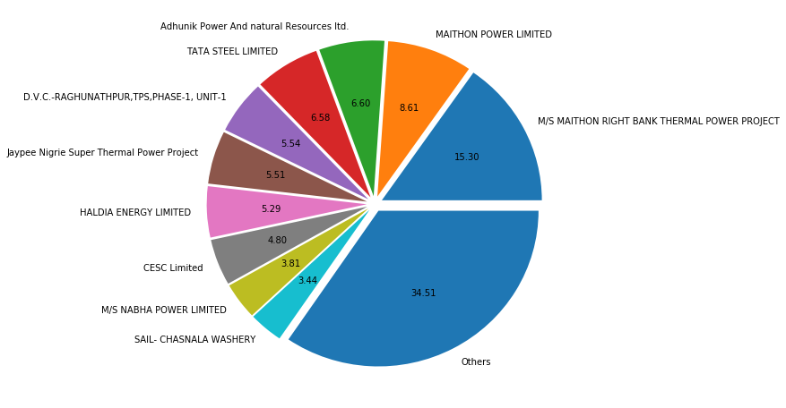

```python
## ANALYSING WITH RESPECT TO NUMBER OF SALES ORDERS

top_ten = df['Consignee Name'].value_counts()[:10]
others = np.sum(df['Consignee Name'].value_counts()[10:])

fig = plt.figure(figsize = (8, 8))
plt.pie(
            np.append(top_ten.values, others),
            labels = list(top_ten.index) + ['Others'],
            explode = [0.05]*11,
            autopct = '%.2f'
        )
plt.show()
```

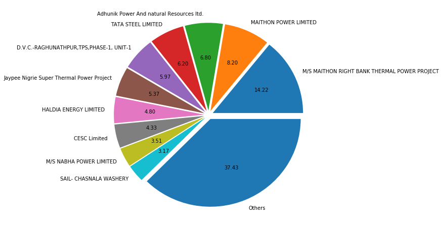

```python
## ANALYSING WITH RESPECT TO TOTAL QUANTITY LIFTED.

temp_df = df[['Consignee Name', 'Quality Lifted']].groupby('Consignee Name').sum().reset_index().sort_values('Quality Lifted', ascending = False)

top_ten = temp_df['Quality Lifted'][:10]
others = np.sum(temp_df['Quality Lifted'][10:])

fig = plt.figure(figsize = (8, 8))
plt.pie(
            np.append(top_ten.values, others),
            labels = list(temp_df['Consignee Name'][:10].values) + ['Others'],
            explode = [0.05]*11,
            autopct = '%.2f'
        )
plt.show()
```

#### Total Quantity Lifted by Consignees (sorted)

```python
temp_df
```

|  | Consignee Name | Quality Lifted |
| --- | --- | --- |
| 373 | M/S MAITHON RIGHT BANK THERMAL POWER PROJECT | 1355050.410 |
| 480 | MAITHON POWER LIMITED | 781563.920 |
| 59 | Adhunik Power And natural Resources ltd. | 647636.650 |
| 856 | TATA STEEL LIMITED | 591152.440 |
| 139 | D.V.C.-RAGHUNATHPUR,TPS,PHASE-1, UNIT-1 | 568611.050 |
| 270 | Jaypee Nigrie Super Thermal Power Project | 511796.290 |
| 196 | HALDIA ENERGY LIMITED | 457792.380 |
| 128 | CESC Limited | 412771.706 |
| 381 | M/S NABHA POWER LIMITED | 334126.942 |
| 666 | SAIL- CHASNALA WASHERY | 302003.680 |
| 144 | DB POWER LIMITED UNIT 1 | 165935.490 |
| 870 | The TATA Power Company Ltd. | 143566.740 |
| 269 | Jaypee Bina Thermal Power Plant | 141316.330 |
| 225 | JAI BALAJI INDUSTRIES LIMITED | 88618.740 |
| 386 | M/S PRAYAGRAJ POWER GENERATION COMPANY LTD. | 79225.380 |
| 473 | MAHARAJA | 53815.690 |
| 476 | MAITHAN ALLOYS LIMITED | 44445.830 |
| 192 | GVK Power (Goindwal Sahib) Limited | 42324.850 |
| 359 | M/S JHAJJHAR POWER LTD.(MGTPP) | 37031.010 |
| 154 | DIAMOND TRADEMART(P)LTD | 34070.490 |
| 471 | MAHADEV COKE LIMITED | 34004.520 |
| 331 | M/S AKASH COKE INDUSTRIES PRIVATE LIMITED | 30751.890 |
| 798 | SINGH NATURAL RESOURCE PVT LTD | 28993.640 |
| 304 | KSK Mahanadi Power Company Limited | 28264.150 |
| 18 | AKASH COKE INDUSTRIES PVT LTD | 27757.480 |
| 664 | SAI RAM ENTERPRISES | 27312.220 |
| 900 | VINAYAK SUPPORT SERVICES PRIVATE LIMITED | 26374.210 |
| 611 | RAI COKE INDUSTRIES PVT LTD | 24520.520 |
| 653 | S.G.PROJECTS LTD. | 23906.950 |
| 86 | BASUDHA UDYOG | 23330.090 |
| ... | ... | ... |
| 63 | B K BROTHERS | 98.920 |
| 98 | BHUMI TRADERS | 96.370 |
| 464 | MAA TARA TRADERS | 96.000 |
| 74 | BALAJI TRADERS | 92.520 |
| 262 | JIVANMATA TRADERS | 86.300 |
| 543 | P.D.TRADERS | 80.830 |
| 261 | JITENDRA YADAV | 80.000 |
| 135 | CHHOTE LAL | 79.250 |
| 635 | RISHAV ENTERPRISES | 79.150 |
| 336 | M/S ASSOCIATED TRADERS | 73.460 |
| 545 | PALI ENTERPRISES | 72.270 |
| 511 | M\S PRATIMA COAL BRIQUETTE | 68.510 |
| 885 | V S ENTERPRISES | 68.110 |
| 218 | J.P.INFRASTRUCTURE | 64.040 |
| 90 | BHAGWATI COKING COALS PRIVATE LIMITED | 63.640 |
| 854 | TANU COAL TRADERS | 60.950 |
| 405 | M/S SHER BAHADUR SINGH | 60.050 |
| 445 | MAA BIMLA UDYOG | 50.300 |
| 908 | YASHASVI ENTERPRISES | 50.000 |
| 65 | B K SINGH & OTHER HUF | 45.820 |
| 153 | DIAMOND SMOKELESS COKE $ COAL COMPLEX | 42.660 |
| 837 | SURAJ GARH BHAGWATI COAL TRADERS | 40.910 |
| 474 | MAHI ENTERPRISES | 40.320 |
| 348 | M/S GAJANAND MULTICOM | 40.290 |
| 784 | SHRI VINAYAK BHANDAR | 40.160 |
| 39 | ANMOL FEEDS PVT.LTD. | 39.660 |
| 286 | KAPIL DEO SINGH & RAJ KUMAR SINGH | 30.570 |
| 866 | TIRVENI COAL TRADERS | 24.630 |
| 273 | K.N.SALES | 20.140 |
| 327 | M. V. ENTERPRISES | 19.950 |

909 rows × 2 columns

### Grade & Size (ProductDescription)

### Analysing the Total Quality Lifted with respect to Grade &Size (Product Description)

- **Washery-4 ROM** and **Washery-4 ROM(POWER PLANT)** are the most Lifted Quanities which alone makeup for about **44%** of Lifted Quantities

```python
df_grouped_w_grade = df[['Grade& Size(Product Description)', 'Quality Lifted']].groupby('Grade& Size(Product Description)').sum().sort_values('Quality Lifted', ascending = False)
df_grouped_w_grade
```

| Grade& Size(Product Description) | Quality Lifted |
| --- | --- |
| Washery-4 ROM | 2384006.756 |
| Washery-4 ROM(POWER PLANT) | 1815555.692 |
| Washery-II ROM | 1076093.770 |
| Washery-3 STM | 817947.450 |
| G8 (4901 KCal/Kg - 5200 KCal/Kg) ROM | 774609.320 |
| Washery-3 STM/FSA | 359009.910 |
| G8 (4901 KCal/Kg - 5200 KCal/Kg) ROM(POWER PLANT) | 255544.140 |
| Washery-4 STM | 173644.330 |
| Washery-4 STM/FSA | 167181.580 |
| Washery-2 STM/FSA | 119650.830 |
| G9 (4601 KCal/Kg - 4900 KCal/Kg) ROM(POWER PLANT) | 111992.130 |
| G6 (5501 KCal/Kg - 5800 KCal/Kg) ROM(POWER PLANT) | 108316.100 |
| Rejects-Ungraded NO SIZE | 107823.800 |
| Washery-3 STM/LKE | 106055.770 |
| G10 (4301 KCal/Kg - 4600 KCal/Kg) ROM | 101000.780 |
| G9 (4601 KCal/Kg - 4900 KCal/Kg) ROM | 99993.460 |
| Steel Grade II ROM | 95237.690 |
| Washery-II ROM/LKE(STEEL) | 88618.740 |
| Slurry Washery - IV SLURRY | 81404.760 |
| G7 (5201 KCal/Kg - 5500 KCal/Kg) ROM(POWER PLANT) | 78359.310 |
| Washery-3 ROM | 70248.300 |
| Washery-3 ROM(POWER PLANT) | 56322.220 |
| Washery-III ROM | 55536.860 |
| AT 34% ASH WASHED POWER COAL(WPC) | 43474.130 |
| G6 (5501 KCal/Kg - 5800 KCal/Kg) ROM | 39650.520 |
| W-I(D/F) ROM | 37033.050 |
| G10 (4301 KCal/Kg - 4600 KCal/Kg) ROM(POWER PLANT) | 34842.260 |
| Washery-4 ROM (PREIMUM15PER) | 34499.730 |
| Steel Grade I ROM | 31348.710 |
| ST-1(D/F) ROM | 29380.520 |
| Washery-2 STM | 27844.470 |
| G5 (5801 KCal/Kg - 6100 KCal/Kg) STM | 26991.020 |
| Washery-II ROM (PREIMUM15PER) | 26430.890 |
| Washery-II STM/FSA | 21521.020 |
| Slurry Washery - III SLURRY | 19946.510 |
| Slurry Washery - III SLURRY/MOONIDIH | 19505.070 |
| Washery-2 ROM | 12856.750 |
| Washery-IV STM/FSA | 7307.180 |
| Washery-I STM | 5044.710 |
| Washery-IV ROM | 2944.410 |
| Slurry Washery - IV SLURRY/FSA | 2624.360 |
| G7 (5201 KCal/Kg - 5500 KCal/Kg) STM | 1790.720 |
| Slurry Washery - III SLURRY/FSA | 422.620 |

```python
(2384006.756 + 1815555.692)/np.sum(df['Quality Lifted'])
```

```
0.44068554885985173
```

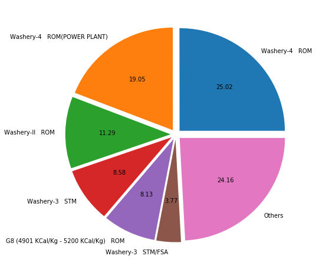

```python
top_ten = df_grouped_w_grade['Quality Lifted'][:6]
others = np.sum(df_grouped_w_grade['Quality Lifted'][6:])

fig = plt.figure(figsize = (8, 8))
plt.pie(
            np.append(top_ten.values, others),
            labels = list(top_ten.index) + ['Others'],
            explode = [0.05]*7,
            autopct = '%.2f'
        )
plt.show()
```

### Loading Date

- The **Density Distribution of the Loading Dates remains somewhat constant during the year**
- July 2018 Consisted of Most Number of Loadings (57,257 times).

```python
df['Loading Date Ordinal'] = df['Loading Date'].apply(lambda x : x.toordinal())
df['Loading Date Month'] = df['Loading Date'].apply(lambda x : datetime.datetime.strftime(x, "%Y -%m (%B)"))
```

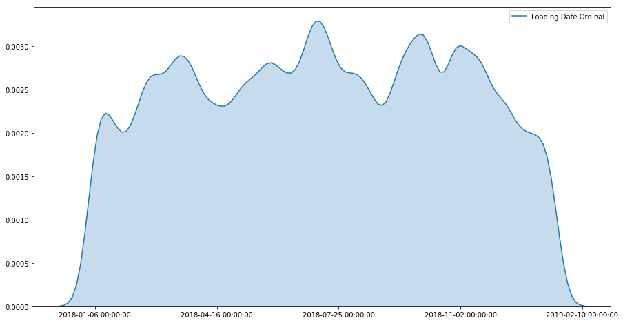

```python
fig = plt.figure(figsize = (15, 8))
ax = sns.kdeplot(df['Loading Date Ordinal'], shade = True)
ax.set_xticklabels(texts)
# as_fig.set(xticks = np.arange(1, 13, 1))
plt.show()
```

#### Numbers Of Loadings Per Month

```python
df['Loading Date Month'].value_counts().reset_index().sort_values('index').set_index('index')
```

| index | Loading Date Month |
| --- | --- |
| 2018 -01 (January) | 41189 |
| 2018 -02 (February) | 41876 |
| 2018 -03 (March) | 50956 |
| 2018 -04 (April) | 40345 |
| 2018 -05 (May) | 50007 |
| 2018 -06 (June) | 47743 |
| 2018 -07 (July) | 57257 |
| 2018 -08 (August) | 45902 |
| 2018 -09 (September) | 50602 |
| 2018 -10 (October) | 53731 |
| 2018 -11 (November) | 49731 |
| 2018 -12 (December) | 41146 |
| 2019 -01 (January) | 23050 |

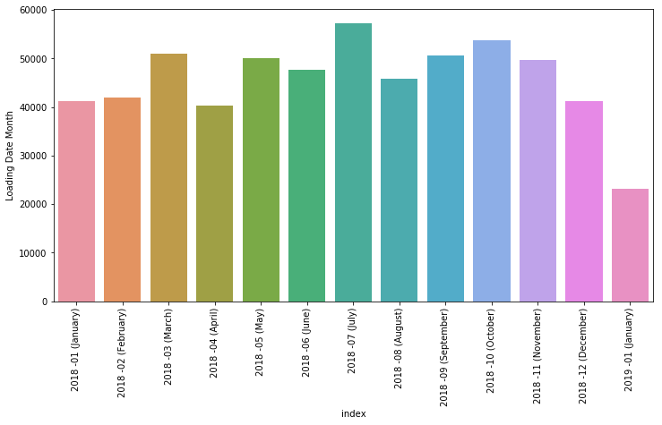

```python
fig =plt.figure(figsize = (12, 6))
temp_df = df['Loading Date Month'].value_counts().reset_index().sort_values('index')
g = sns.barplot(x = 'index', y = 'Loading Date Month', data = temp_df)
plt.xticks(rotation=90)
del temp_df
```

### Quality Lifted

- On analysing the frequency distributions of the Quality Lifted, the **most frequently lifted quantity** lies close to **15**.
- The total Quality Lifted was 9529612.348

```python
np.sum(df['Quality Lifted'])
```

```
9529612.348
```

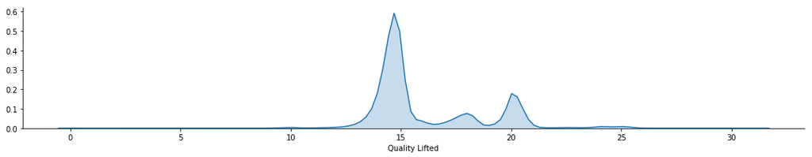

```python
as_fig = sns.FacetGrid(df,aspect=5)
# sns.kdeplot(df['Quality Lifted'], shade = True)
as_fig.map(sns.kdeplot,'Quality Lifted',shade=True)
plt.show()
```

### Sales Order Date

- The **frequency distribution of Sales Orders remained more or less constant this year**.
- Most no. of Sales Orders were given on February 2018 (58,771)

```python
df['Sales Order Date Ordinal'] = df['Sales Order Date'].apply(lambda x : x.toordinal())
df['Sales Order Date Month'] = df['Sales Order Date'].apply(lambda x : datetime.datetime.strftime(x, "%Y: %m(%B)"))
```

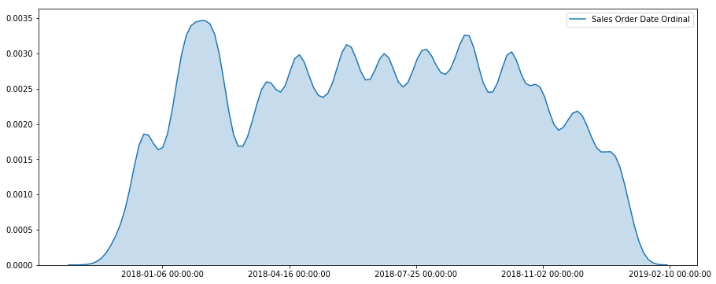

```python
fig = plt.figure(figsize = (15, 6))
ax = sns.kdeplot(df['Sales Order Date Ordinal'],shade=True)
texts = [datetime.datetime.fromordinal(int(i)) for i in ax.get_xticks()]
ax.set_xticklabels(texts)
plt.show()
```

```python
df['Sales Order Date Month'].value_counts().reset_index().sort_values('index').set_index('index')
```

| index | Sales Order Date Month |
| --- | --- |
| 2017: 11(November) | 1546 |
| 2017: 12(December) | 24792 |
| 2018: 01(January) | 43543 |
| 2018: 02(February) | 58771 |
| 2018: 03(March) | 37253 |
| 2018: 04(April) | 47600 |
| 2018: 05(May) | 44486 |
| 2018: 06(June) | 52963 |
| 2018: 07(July) | 47753 |
| 2018: 08(August) | 51564 |
| 2018: 09(September) | 50127 |
| 2018: 10(October) | 56651 |
| 2018: 11(November) | 35521 |
| 2018: 12(December) | 32920 |
| 2019: 01(January) | 8045 |

### Sales Order Number

- 21,140 Unique Sales Order Numbers exist among 593,535 total Sales Order Numbers
- Sales Order Numbers 18052216852, and 19000100179 had the highest Sales Order Quantity

```python
len(df['Sales Order No'].unique())
```

```
21140
```

#### Top Sales Orders wrt. Total Quality Lifted (sorted)

- `CESC Limited` Lifted the maximum 40,000.00 and 39999.86

```python
top_sales_order_no = df[['Sales Order No', 'Consignee Name', 'Quality Lifted']].groupby(['Sales Order No', 'Consignee Name']).sum().sort_values('Quality Lifted', ascending = False)
top_sales_order_no[:10]
```

| Sales Order No | Consignee Name | Quality Lifted |
| --- | --- | --- |
| 18052216852 | CESC Limited | 40000.00 |
| 19000100179 | CESC Limited | 39999.86 |
| 18790217001 | Adhunik Power And natural Resources ltd. | 36021.03 |
| 19729804361 | Adhunik Power And natural Resources ltd. | 35000.00 |
| 18779714720 | Adhunik Power And natural Resources ltd. | 30000.00 |
| 19008605751 | Adhunik Power And natural Resources ltd. | 29999.91 |
| 19006011321 | Adhunik Power And natural Resources ltd. | 29997.11 |
| 18704014676 | D.V.C.-RAGHUNATHPUR,TPS,PHASE-1, UNIT-1 | 24298.05 |
| 19001104665 | TATA STEEL LIMITED | 22999.90 |
| 19008304362 | Adhunik Power And natural Resources ltd. | 20499.53 |

### Area and Colliery

#### Total 593,535 Loadings took place between 01<sup>st</sup> January 2018 to 19<sup>th</sup> January 2019

- **Katras Area** had the maximum number of Loadings - 147,133
- **West Mudidih** Colliery in **Katras Area** Had the maximum numbers of loadings - 78,591

#### Area-Wise Loadings DIsributions

```python
df['area_name'].value_counts()
```

```
Katras Area        147133
Sijua Area         118929
Kusunda Area        90341
Lodna Area          74843
C.V. Area           35595
E.J. Area           32629
Bastacolla Area     22869
Barora Area         18909
Govindpur Area      16820
Block-II Area       15070
EWZ                  7912
Washery Div.         5565
P.B.Area             4524
WWZ                  2223
Madhuban-W            173
Name: area_name, dtype: int64
```

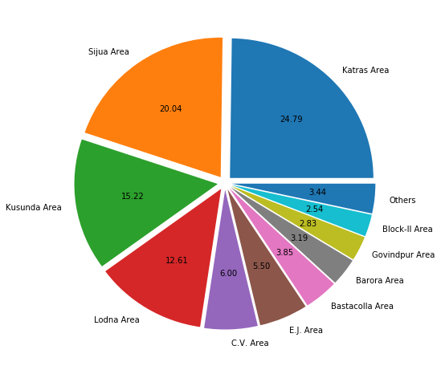

```python
top_ten = df['area_name'].value_counts()[:10]
others = np.sum(df['area_name'].value_counts()[10:])

fig = plt.figure(figsize = (8, 8))
plt.pie(
            np.append(top_ten.values, others),
            labels = list(top_ten.index) + ['Others'],
            explode = [0.05]*11,
            autopct = '%.2f'
        )
plt.show()
```

#### Colliery wise Loadings Distributions (sorted)

```python
df['colliery_name'].value_counts()
```

```
West Mudidih             78591
Godhur                   42079
North Tisra              38770
Katras Chaitudih         26675
Kankanee                 25971
North Tisra - SSY        24185
Sendra Bansjora - SSY    22909
AKWMC                    22338
Gondudih                 20841
3 Pit OCP                20816
Tetulmari - SSY          16022
Damagoria                14446
East Bassuriya           13654
Nichitpur                13460
Sendra Bansjora          13409
Tetulmari                12983
Nichitpur SSY            12187
C. O.C.P (Sudamdih)      11192
Dahibari OCP-SSY         10943
West Mudidih OCP         10931
R.O.C.P                   7358
Golukdih (Kuiya OCP)      6827
Dhansar                   6740
Damagoria O.C.P           6596
Akashkinare - SSY         6343
J.O.C.P SSY               6334
Bararee                   5497
Dhansar - SSY             5333
Jeenagora                 5333
Phularitand               5270
                         ...
Gazlitand                 3997
Sudamdih-W                3708
Dahibari                  3610
Muraidih                  3525
Salanpur                  3229
Dobari                    3210
Dugda-W                   3108
P.B Project               2506
Ghanoodih O.C.P           2469
Patherdih-W               2457
Moonidih-W                2223
Bhagaband                 2018
Mudidih                   1988
Block IV - SSY            1920
Maheshpur                 1884
ENA                       1519
Bastacola -SSY            1416
SALANPUR O.C.P            1372
Kharkharee                1314
Dobari-SSY                1180
Jeenagora - SSY           1058
Phularitand - SSY          998
Block-IV                   778
Bhowra-North               450
Kuiya                      329
K.O.C.P                    175
Madhuban-W                 173
Bhowra-South               171
Jogidih SSY                166
Bastacola                   80
Name: colliery_name, Length: 66, dtype: int64
```

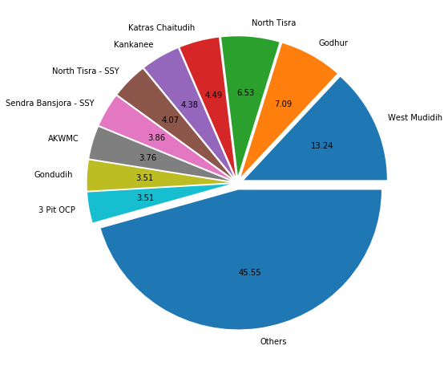

```python
top_ten = df['colliery_name'].value_counts()[:10]
others = np.sum(df['colliery_name'].value_counts()[10:])

fig = plt.figure(figsize = (8, 8))
plt.pie(
            np.append(top_ten.values, others),
            labels = list(top_ten.index) + ['Others'],
            explode = [0.05]*11,
            autopct = '%.2f'
        )
plt.show()
```

### Delay Between Loading Date and Sales Order Data

- **Most of the consignments were Loaded within 20 Days of Sales Order Date**
- 311,829 Sales Orders Were Loaded within 20 Days of Booking
- 535,838 (90%) Sales Orders Were Loaded within 40 Days Of Booking

```python
delay = [i- j for i, j in df[['Loading Date', 'Sales Order Date']].values]
df['delay'] = delay
df['delay'] = df['delay'].astype('timedelta64[D]')
```

```python
df['delay-bracket'] = df['delay'].apply(lambda x : str((x//20) * 20) + ' - ' + str(((x//20) * 20) + 20))
```

```python
df['delay-bracket'].value_counts()
```

```
0.0 - 20.0       311829
20.0 - 40.0      224009
40.0 - 60.0       54010
80.0 - 100.0       1101
160.0 - 180.0      1034
100.0 - 120.0       821
220.0 - 240.0       292
140.0 - 160.0       289
260.0 - 280.0        97
60.0 - 80.0          50
-40.0 - -20.0         2
240.0 - 260.0         1
Name: delay-bracket, dtype: int64
```

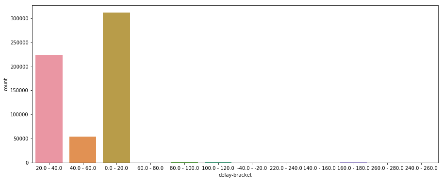

```python
fig = plt.figure(figsize = (15, 6))
ax = sns.countplot(df['delay-bracket'])
# texts = [i for i in ax.get_xticks()]
# ax.set_yticklabels(texts)
plt.show()
```

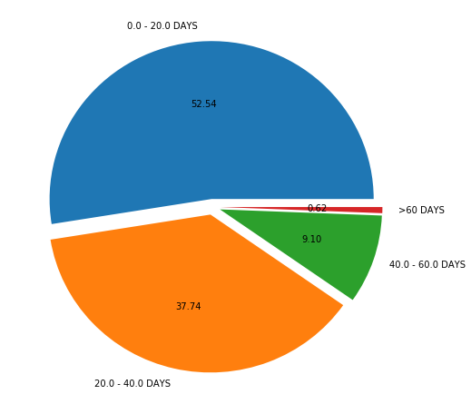

```python
top_three = df['delay-bracket'].value_counts()[:3]
others = np.sum(df['delay-bracket'].value_counts()[3:])

fig = plt.figure(figsize = (8, 8))
plt.pie(
            np.append(top_three.values, others),
            labels = [i + ' DAYS' for i in list(top_three.index)] + ['>60 DAYS'],
            explode = [0.05]*4,
            autopct = '%.2f'
        )
plt.show()
```